# Project 2: Data Mining, Classification, Prediction

### Linear Classifier

```r
median(projdata$Popularity)
```

```
## [1] 67.5
```

```r
yhat <- ifelse(projdata$Popularity > 67.5, "popular", "unpopular")
yhat <- factor(yhat, levels = c("popular", "unpopular"))

logistic_fit <- glm(yhat == "popular" ~ danceability + energy +
    acousticness + instrumentalness + tempo, data = projdata,
    family = "binomial")

prob_reg <- predict(logistic_fit, type = "response")

class_diag(prob_reg, truth = yhat, positive = "popular")
```

```
##           acc   sens   spec   ppv    f1    ba    auc
## Metrics 0.742 0.8351 0.6489 0.704 0.764 0.742 0.8367
```

```r
pred <- sample(c("popular", "unpopular"), size = length(yhat),
    replace = T)

table(actual = pred, predicted = yhat)
```

```
##            predicted
## actual      popular unpopular
##   popular        94        84
##   unpopular      94       104
```

```r
projdata <- projdata %>% mutate(yhat = ifelse(projdata$Popularity >
    67.5, "popular", "unpopular"))

k = 10

data <- sample_frac(projdata)
folds <- rep(1:k, length.out = nrow(data))

diags <- NULL

i = 1
for (i in 1:k) {

    train <- data[folds != i, ]
    test <- data[folds == i, ]
    truth <- test$yhat


    fit <- glm(yhat == "popular" ~ danceability + energy + acousticness +
        instrumentalness + tempo, data = train, family = "binomial")



    probs <- predict(fit, newdata = test, type = "response")



    diags <- rbind(diags, class_diag(probs, truth, positive = "popular"))
}


summarize_all(diags, mean)
```

```
##       acc   sens   spec     ppv      f1      ba     auc
## 1 0.73699 0.8291 0.6379 0.69406 0.75187 0.73349 0.82837
```

Based on the AUC (0.83), this model is predicting new observations well. The AUC after cross validation is approximately the same as the AUC before cross validation, so this model does not show signs of overfitting.

### Non-Parametric Classifier

```r
library(caret)

knn_fit <- knn3(yhat == "popular" ~ danceability + energy + acousticness +
    instrumentalness + tempo, data = projdata)

prob_knn <- predict(knn_fit, projdata)

class_diag(prob_knn[, 2], projdata$yhat, positive = "popular")
```

```
##            acc   sens   spec    ppv     f1     ba    auc
## Metrics 0.9255 0.9096 0.9415 0.9396 0.9243 0.9255 0.9832
```

```r
pred <- sample(c("popular", "unpopular"), size = length(yhat),
    replace = T)

table(actual = pred, predicted = yhat)
```

```
##            predicted
## actual      popular unpopular
##   popular        92        98
##   unpopular      96        90
```

```r
k = 10

data <- sample_frac(projdata)
folds <- rep(1:k, length.out = nrow(data))

diags <- NULL

i = 1
for (i in 1:k) {

    train <- data[folds != i, ]
    test <- data[folds == i, ]
    truth <- test$yhat


    fit <- knn3(yhat == "popular" ~ danceability + energy + acousticness +
        instrumentalness + tempo, data = train)

    probs <- predict(fit, newdata = test)[, 2]


    diags <- rbind(diags, class_diag(probs, truth, positive = "popular"))
}


summarize_all(diags, mean)
```

```
##       acc    sens    spec     ppv      f1      ba     auc
## 1 0.85657 0.82468 0.88657 0.88368 0.85016 0.85564 0.95103
```

### Regression/Numeric Prediction

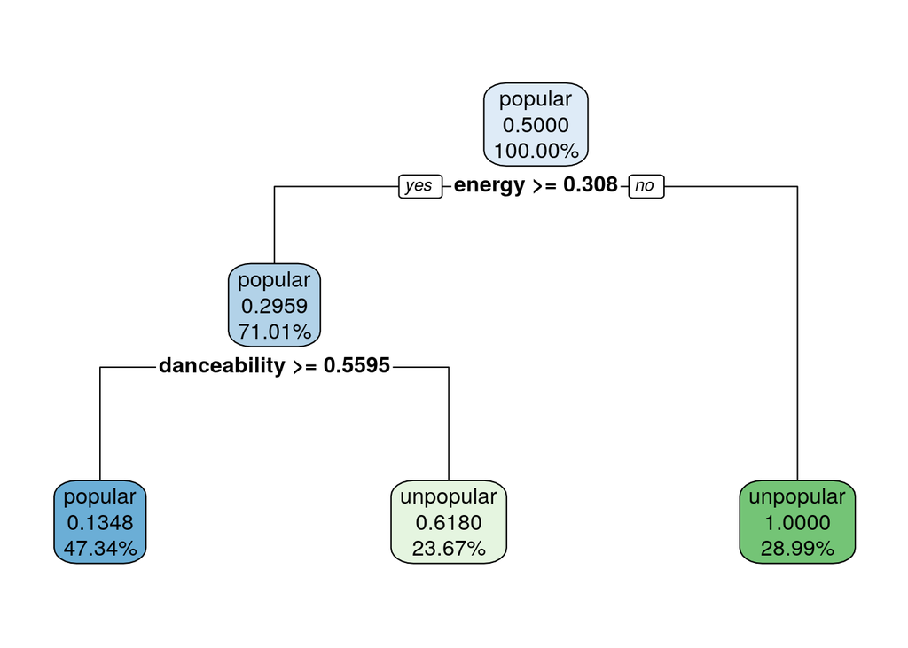

```r
fit <- train(yhat ~ danceability + energy + acousticness + instrumentalness +
    tempo, data = projdata, method = "rpart")
library(rpart.plot)
rpart.plot(fit$finalModel, digits = 4)
```

```r
fit <- lm(danceability ~ energy + acousticness + instrumentalness +
    tempo, data = projdata)
pred_fit <- predict(fit)
mean((projdata$danceability - pred_fit)^2)
```

```
## [1] 0.02233853
```

```r
k = 10
data <- projdata[sample(nrow(projdata)), ]
folds <- cut(seq(1:nrow(projdata)), breaks = k, labels = F)
diags <- NULL
for (i in 1:k) {
    train <- data[folds != i, ]
    test <- data[folds == i, ]

    fit <- lm(danceability ~ energy + acousticness + instrumentalness +
        tempo, data = projdata)

    pred_fit <- predict(fit, newdata = test)

    diags <- mean((test$danceability - pred_fit)^2)
}
mean(diags)
```

```
## [1] 0.02191275
```

I included a classification tree to show the likelihood of a song being popular based on various factors. I then found the MSE of danceability compared to the other confounding variables (0.02). Next, I performed a cross validation and found the average MSE across the folds (0.02). These MSEs were approximately the same, which indicates that there are no signs of overfitting in this model.

### Python

```r
library(reticulate)

head(projdata)
```

```
## # A tibble: 6 x 9
##      X1  year Popularity danceability energy acousticness instrumentalness tempo
##   <dbl> <dbl>      <dbl>        <dbl>  <dbl>        <dbl>            <dbl> <dbl>
## 1     1  2020         66        0.696  0.229       0.828        0.0000134  113.
## 2     2  2020         72        0.608  0.524       0.367        0.00254     86.2
## 3     3  2020         68        0.674  0.413       0.836        0.0000195  125.
## 4     4  2020         64        0.547  0.216       0.924        0.214       79.9
## 5     5  2020         76        0.526  0.749       0.023        0.00000176 100.
## 6     6  2020         85        0.399  0.491       0.0563       0.00089     91.1
## # … with 1 more variable: yhat <chr>
```

```python
projdata = r.projdata

type(projdata)
```

```
## <class 'dict'>
```

Here, the projdata dataset was loaded into a Python chunk. Python was used to describe what type of object projdata is.